# Recurrent Neural Networks (RNN) for Multivariate Time Series Forecasting

## Overview

This notebook explores the use of Recurrent Neural Networks (RNNs) for time series forecasting using the **lstm-datasets-multivariate-univariate** dataset from Kaggle: https://www.kaggle.com/datasets/rupakroy/lstm-datasets-multivariate-univariate/

The dataset consists of multi-dimensional weather-related time-series data, allowing us to predict future values of the **pollution** based on historical trends.

## Notebook Content

1. **Data handing**: Importing the dataset, handling missing values, and normalizing the data, select relevant variables, split and transforming the dataset for model input.
2. **Model Architecture**: Implementing a RNN network for both multivariate forecasting.
3. **Training the Model**: Running experiments. No tuning hyperparameters, and optimizing performance is present.
4. **Evaluation**: Measuring forecast accuracy using MSE metric.
5. **Results & Discussion**: Analyzing performance showing the predicted vs real time-series.

This notebook serves **solely** as an educational and demostrative guide for applying deep learning models to time series forecasting problems.

```python
import time
import pandas as pd
import numpy as np
import matplotlib.pyplot as plt
import matplotlib.cm as cm
import seaborn as sns
from math import sqrt
import torch
import torch.nn as nn
import torch.optim as optim
from torch.utils.data import DataLoader, TensorDataset
from sklearn.preprocessing import MinMaxScaler
from sklearn.metrics import mean_squared_error
from tqdm import tqdm
```

### Read and check the dataset

```python
df = pd.read_csv('data/LSTM-Multivariate_pollution.csv')
df_test = pd.read_csv("data/pollution_test_data1.csv")
df
```

|  | date | pollution | dew | temp | press | wnd_dir | wnd_spd | snow | rain |
| --- | --- | --- | --- | --- | --- | --- | --- | --- | --- |
| 0 | 2010-01-02 00:00:00 | 129.0 | -16 | -4.0 | 1020.0 | SE | 1.79 | 0 | 0 |
| 1 | 2010-01-02 01:00:00 | 148.0 | -15 | -4.0 | 1020.0 | SE | 2.68 | 0 | 0 |
| 2 | 2010-01-02 02:00:00 | 159.0 | -11 | -5.0 | 1021.0 | SE | 3.57 | 0 | 0 |
| 3 | 2010-01-02 03:00:00 | 181.0 | -7 | -5.0 | 1022.0 | SE | 5.36 | 1 | 0 |
| 4 | 2010-01-02 04:00:00 | 138.0 | -7 | -5.0 | 1022.0 | SE | 6.25 | 2 | 0 |
| ... | ... | ... | ... | ... | ... | ... | ... | ... | ... |
| 43795 | 2014-12-31 19:00:00 | 8.0 | -23 | -2.0 | 1034.0 | NW | 231.97 | 0 | 0 |
| 43796 | 2014-12-31 20:00:00 | 10.0 | -22 | -3.0 | 1034.0 | NW | 237.78 | 0 | 0 |
| 43797 | 2014-12-31 21:00:00 | 10.0 | -22 | -3.0 | 1034.0 | NW | 242.70 | 0 | 0 |
| 43798 | 2014-12-31 22:00:00 | 8.0 | -22 | -4.0 | 1034.0 | NW | 246.72 | 0 | 0 |
| 43799 | 2014-12-31 23:00:00 | 12.0 | -21 | -3.0 | 1034.0 | NW | 249.85 | 0 | 0 |

43800 rows × 9 columns

```python
df_test
```

|  | dew | temp | press | wnd_dir | wnd_spd | snow | rain | pollution |
| --- | --- | --- | --- | --- | --- | --- | --- | --- |
| 0 | -16 | 4 | 1027 | SE | 3.58 | 0 | 0 | 128 |
| 1 | -17 | 5 | 1027 | SE | 7.60 | 0 | 0 | 77 |
| 2 | -16 | 4 | 1027 | SE | 9.39 | 0 | 0 | 65 |
| 3 | -16 | 1 | 1028 | cv | 0.89 | 0 | 0 | 79 |
| 4 | -14 | 0 | 1028 | NE | 1.79 | 0 | 0 | 93 |
| ... | ... | ... | ... | ... | ... | ... | ... | ... |
| 341 | -23 | -2 | 1034 | NW | 231.97 | 0 | 0 | 8 |
| 342 | -22 | -3 | 1034 | NW | 237.78 | 0 | 0 | 10 |
| 343 | -22 | -3 | 1034 | NW | 242.70 | 0 | 0 | 10 |
| 344 | -22 | -4 | 1034 | NW | 246.72 | 0 | 0 | 8 |
| 345 | -21 | -3 | 1034 | NW | 249.85 | 0 | 0 | 12 |

346 rows × 8 columns

The test dataset miss the timestamp. We have toconsider the element already sorted correctly.

```python
#Get general information about the dataset
df.info()
```

```
<class 'pandas.core.frame.DataFrame'>
RangeIndex: 43800 entries, 0 to 43799
Data columns (total 9 columns):
 #   Column     Non-Null Count  Dtype
---  ------     --------------  -----
 0   date       43800 non-null  object
 1   pollution  43800 non-null  float64
 2   dew        43800 non-null  int64
 3   temp       43800 non-null  float64
 4   press      43800 non-null  float64
 5   wnd_dir    43800 non-null  object
 6   wnd_spd    43800 non-null  float64
 7   snow       43800 non-null  int64
 8   rain       43800 non-null  int64
dtypes: float64(4), int64(3), object(2)
memory usage: 3.0+ MB
```

```python
# Checking null values
print(df.isnull().sum() , "\n---------------- \n" , df_test.isnull().sum() )
```

```
date         0
pollution    0
dew          0
temp         0
press        0
wnd_dir      0
wnd_spd      0
snow         0
rain         0
dtype: int64
----------------
 dew          0
temp         0
press        0
wnd_dir      0
wnd_spd      0
snow         0
rain         0
pollution    0
dtype: int64
```

## Feature Encoding

```python
df['wnd_dir'].unique()
```

```
array(['SE', 'cv', 'NW', 'NE'], dtype=object)
```

```python
direction_mapping = {
    'N': 0,    # North
    'NE': 1,   # Northeast
    'E': 2,    # East
    'SE': 3,   # Southeast
    'S': 4,    # South
    'SW': 5,   # Southwest
    'W': 6,    # West
    'NW': 7,   # Northwest
    'cv': 8    #Present in the dataset but unown
}


# Replace the string values with numerical values
df['wnd_dir'] = df['wnd_dir'].map(direction_mapping)
df_test['wnd_dir'] = df_test['wnd_dir'].map(direction_mapping)

df['date'] = pd.to_datetime(df['date'])
# Resetting the index
df.set_index('date', inplace=True)
df.head()
```

| date | pollution | dew | temp | press | wnd_dir | wnd_spd | snow | rain |
| --- | --- | --- | --- | --- | --- | --- | --- | --- |
| 2010-01-02 00:00:00 | 129.0 | -16 | -4.0 | 1020.0 | 3 | 1.79 | 0 | 0 |
| 2010-01-02 01:00:00 | 148.0 | -15 | -4.0 | 1020.0 | 3 | 2.68 | 0 | 0 |
| 2010-01-02 02:00:00 | 159.0 | -11 | -5.0 | 1021.0 | 3 | 3.57 | 0 | 0 |
| 2010-01-02 03:00:00 | 181.0 | -7 | -5.0 | 1022.0 | 3 | 5.36 | 1 | 0 |
| 2010-01-02 04:00:00 | 138.0 | -7 | -5.0 | 1022.0 | 3 | 6.25 | 2 | 0 |

### Data Exploration

- Plot the time series of the features.
- Plot the histogram of the features to gain some knowledge.

**notice**: here is possible because we have few, interpretable features

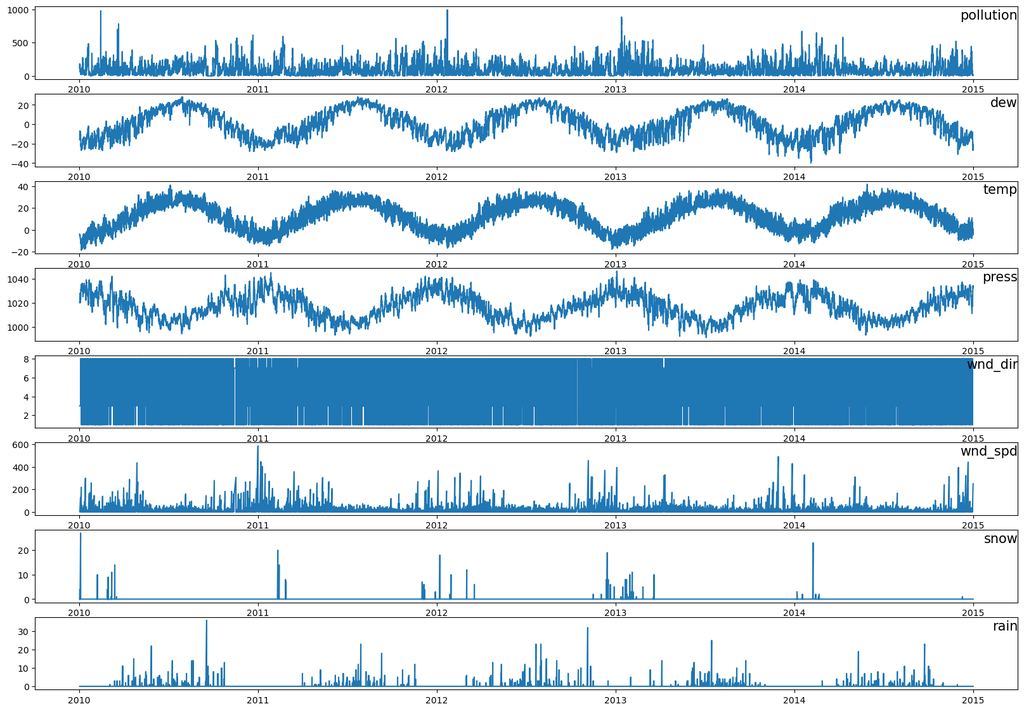

```python
i = 1
# plot each column
plt.figure(figsize=(20,14))
for c in df.columns:
    plt.subplot(len(df.columns), 1, i)
    plt.plot(df[c])
    plt.title(c, y=0.75, loc='right', fontsize = 15)
    i += 1
plt.show()
plt.close()
```

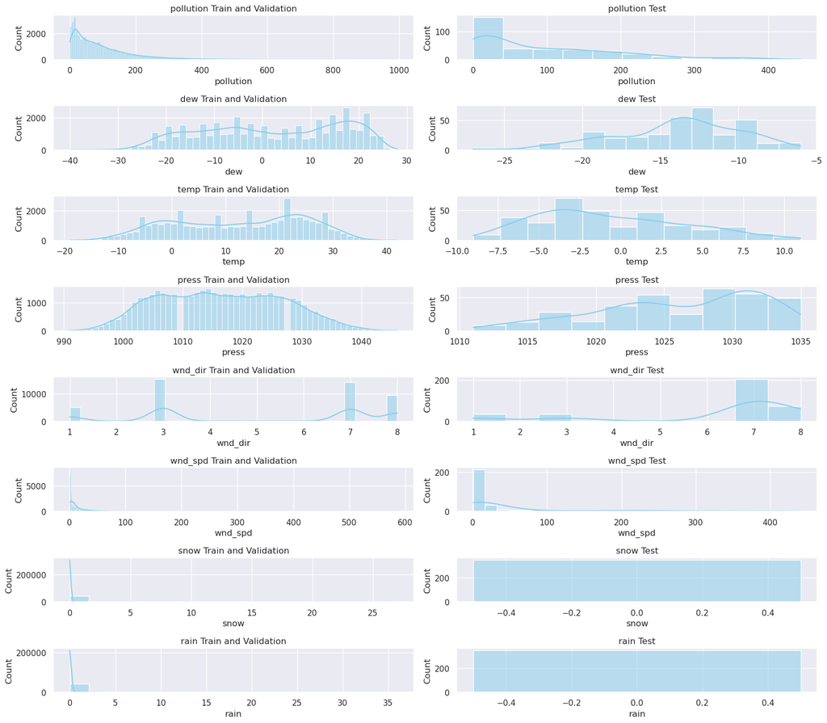

```python
sns.set(style="darkgrid")

fig, axs = plt.subplots(8,2, figsize=(16,14))

i=0
for c in df.columns:
    axs[i, 0].set_title(c+ " Train and Validation")
    sns.histplot(data=df, x=c, kde=True, color="skyblue", ax=axs[i, 0])
    axs[i, 1].set_title(c+ " Test")
    sns.histplot(data=df_test, x=c, kde=True, color="skyblue", ax=axs[i, 1])
    i+=1

plt.tight_layout()
plt.show()
plt.close()
```